# Summarizing Distributions

X610 · Session 2 · *FoAS* Chapter 2

## Today

- Expected values, moments, variance, and measures of dispersion
- Mean squared error and the expected value as the best constant predictor
- Covariance, correlation, conditional expectation, and conditional variance
- Conditional expectation functions, best linear predictors, and multivariate generalizations

Reading: *FoAS* Ch. 2; *Bernoulli’s Fallacy* Ch. 2

# Expectation and moments

## Notation: new this session

| Notation | Definition and usage |
| --- | --- |
| $\arg\max$ | The value, among all values in a particular set, that maximizes the given expression. For example, $\operatorname{argmax}_{x \in \mathbb{R}}(-x^2 - 2x + 3) = -1$. Assumes a unique maximum. |
| $\arg\min$ | The value that minimizes the given expression. For example, $\operatorname{argmin}_{x \in \mathbb{R}}(x^2 - 4x + 1) = 2$. Assumes a unique minimum. |

## Expected value

**Definition 2.1.1 — Expected Value**

For a discrete random variable $X$ with PMF $f$ the expected value of $X$ is
$$\mathrm{E}[X] = \sum_x x f(x).$$
For a continuous random variable $X$ with PDF $f$, the expected value of $X$ is
$$\mathrm{E}[X] = \int_{-\infty}^{\infty} x f(x)\, dx.$$
Regularity conditions in both cases ensure the sums/integrals converge absolutely.

- An *operator*: takes a random variable, returns a number
- The probability-weighted average of the possible values

## Two simple examples

**Example 2.1.2 — A Fair Die Roll**

$$\mathrm{E}[X] = \sum_{x=1}^{6} x \cdot \frac{1}{6} = \frac{7}{2}.$$

Note that $X$ never takes the value $3.5$. A random variable need not take its expected value with positive probability.

**Example 2.1.3 — Bernoulli Distribution**

$$\mathrm{E}[X] = 0 \cdot (1 - p) + 1 \cdot p = p,$$
so means of binary variables *are probabilities*.

## Expectations of functions

**Theorem 2.1.5 — Expectation of a Function of a Random Variable**

If $X$ is a discrete random variable with PMF $f$ and $g$ is a function of $X$, then
$$\mathrm{E}[g(X)] = \sum_x g(x) f(x).$$
If $X$ is a continuous random variable with PDF $f$ and $g$ is a function of $X$, then
$$\mathrm{E}[g(X)] = \int_{-\infty}^{\infty} g(x) f(x)\, dx.$$

- Just weight $g(x)$ by the original PMF/PDF
- In general $\mathrm{E}[g(X)] \neq g(\mathrm{E}[X])$

## Linearity of expectations

**Theorem 2.1.9 — Linearity of Expectations**

Let $X$ and $Y$ be random variables. Then, $\forall a, b, c \in \mathbb{R}$,
$$\mathrm{E}[aX + bY + c] = a\mathrm{E}[X] + b\mathrm{E}[Y] + c.$$

- Holds with **no assumptions** about the relationship between $X$ and $Y$ — dependent, independent, $\ldots$ it doesn’t matter

## Linearity, verified

```python
n = 1_000_000
X = rng.integers(1, 7, size=n)          # die roll
Y = X + rng.exponential(size=n)         # strongly dependent on X

print('E[2X + 3Y + 1] ≈', (2 * X + 3 * Y + 1).mean())
print('2E[X]+3E[Y]+1  ≈', 2 * X.mean() + 3 * Y.mean() + 1)
```

```
E[2X + 3Y + 1] ≈ 21.505361469279705
2E[X]+3E[Y]+1  ≈ 21.505361469279705
```

- Dependence between $X$ and $Y$ is irrelevant — linearity doesn’t care

## Moments

**Definition 2.1.10 — j-th Raw Moment**

For a random variable $X$ and $j \in \mathbb{N}$, the $j$-th raw moment of $X$ is $\mu_j' = \mathrm{E}[X^j]$.

**Definition 2.1.11 — j-th Central Moment**

For a random variable $X$ and $j \in \mathbb{N}$, the $j$-th central moment of $X$ is $\mu_j = \mathrm{E}\left[(X - \mathrm{E}[X])^j\right]$.

- The first raw moment is the *expected value*;
  - the first central moment is always zero
- The second central moment has its own name…

## Variance

**Definition 2.1.12 — Variance**

The variance of a random variable $X$ is
$$\mathrm{V}[X] = \mathrm{E}\left[(X - \mathrm{E}[X])^2\right].$$

Since $\mathrm{E}[X]$ is a constant, expand the square and apply linearity:
$$\begin{aligned}
\mathrm{V}[X]
&= \mathrm{E}\left[X^2 - 2X\mathrm{E}[X] + \mathrm{E}[X]^2\right] \\
&= \mathrm{E}[X^2] - 2\mathrm{E}[X]^2 + \mathrm{E}[X]^2 \\
&= \mathrm{E}[X^2] - \mathrm{E}[X]^2.
\end{aligned}$$

## Variance and standard deviation

**Theorem 2.1.13 — Alternative Formula for Variance**

For a random variable $X$,
$$\mathrm{V}[X] = \mathrm{E}[X^2] - \mathrm{E}[X]^2.$$

**Definition 2.1.15 — Standard Deviation**

$$\sigma[X] = \sqrt{\mathrm{V}[X]}$$

## Die roll example

For a fair die, $\mathrm{E}[X] = 3.5$. Therefore,
$$\begin{aligned}
\mathrm{V}[X]
&= \frac{1}{6}\sum_{x=1}^{6}\left(x - 3.5\right)^2
= \tfrac{1}{6}\left(2\cdot 2.5^2 + 2\cdot 1.5^2 + 2\cdot 0.5^2\right) \\
& = \tfrac{35}{12} \approx 2.92
\end{aligned}$$

Note also that
$$\E[X^2] = \tfrac{1}{6}(1 + 2^2 + 3^2 + 4^2 + 5^2 + 6^2) = \tfrac{91}{6},$$

so $\V[X] = \E[X^2] - \E[X]^2 = \tfrac{91}{6} - \tfrac{49}{4} = \tfrac{35}{12}.$

## Die roll moments in python

```python
X = stats.randint(1, 7)  # fair die: values 1 through 6
mean = X.moment(1)
second_moment = X.moment(2)

print('E[X] =', mean)
print('E[X²] =', second_moment)
print('V[X] from deviations =', X.expect(lambda x: (x - mean) ** 2))
print('V[X] from moments =', second_moment - mean ** 2)
```

```
E[X] = 3.5
E[X²] = 15.166666666666666
V[X] from deviations = 2.9166666666666665
V[X] from moments = 2.916666666666666
```

## How variance and SD transform

**Theorems 2.1.14 and 2.1.16 — Properties of Variance and Standard Deviation**

For a random variable $X$, and $a, c \in \mathbb{R}$,

- $\mathrm{V}[X + c] = \mathrm{V}[X]$ and $\mathrm{V}[aX] = a^2 \mathrm{V}[X]$
- $\sigma[X + c] = \sigma[X]$ and $\sigma[aX] = |a|\, \sigma[X]$
- a *shift* doesn’t change the *spread* of a random variable
- but *scaling* does:
  - scales SD linearly, but variance increases quadratically

## Exercise

Let $X \sim B(p)$. What is the variance of $X$?

## Chebyshev’s inequality

**Theorem 2.1.18 — Chebyshev’s Inequality**

Let $X$ be a random variable with finite $\sigma[X] > 0$. Then, $\forall \epsilon > 0$,
$$\Pr\big[|X - \mathrm{E}[X]| \geq \epsilon\, \sigma[X]\big] \leq \frac{1}{\epsilon^2}.$$

- Knowing only the mean and SD bounds the tails for **any** distribution
- At most $\frac{1}{4}$ of probability lies beyond 2 SDs; at most $\frac{1}{9}$ beyond 3 SDs

## How tight is Chebyshev?

```python
tight = stats.rv_discrete(values=([-2, 0, 2], [1/8, 3/4, 1/8]))
dists = {'normal': stats.norm(), 'uniform': stats.uniform(),
         'exponential': stats.expon(), 'three-point': tight}

print('eps=2: bound = 0.25')
for name, d in dists.items():
    m, s = d.mean(), d.std()
    actual = d.expect(lambda x: np.abs(x - m) >= 2 * s)
    print(f'  {name:12s} actual = {actual:.4f}')
```

```
eps=2: bound = 0.25
  normal       actual = 0.0455
  uniform      actual = 0.0000
  exponential  actual = 0.0498
  three-point  actual = 0.2500
```

- Familiar distributions fall well below the bound
- The specially constructed 3-point distribution attains it exactly

## The normal distribution

**Definition 2.1.19 — Normal Distribution**

A continuous random variable $X$ follows a normal distribution if it has PDF
$$f(x) = \frac{1}{\sigma\sqrt{2\pi}} e^{-\frac{(x - \mu)^2}{2\sigma^2}}, \; \forall x \in \mathbb{R},$$
for some constants $\mu, \sigma \in \mathbb{R}$ with $\sigma > 0$. We write $X \sim N(\mu, \sigma^2)$.

**Theorem 2.1.20 — Mean and Standard Deviation of the Normal Distribution**

If $X \sim N(\mu, \sigma^2)$, then $\mathrm{E}[X] = \mu$ and $\sigma[X] = \sigma$.

- Two parameters characterize the distribution:
  - $\mu$ shifts it and $\sigma$ scales it

## Normals stay normal

**Theorem 2.1.21 — Properties of the Normal Distribution**

Suppose $X \sim N(\mu_X, \sigma_X^2)$ and $Y \sim N(\mu_Y, \sigma_Y^2)$. Then

- $\forall a, b \in \mathbb{R}$ with $a \neq 0$, if $W = aX + b$, then $W \sim N(a\mu_X + b, a^2\sigma_X^2)$.
- If $X \perp\!\!\!\perp Y$ and $Z = X + Y$, then $Z \sim N(\mu_X + \mu_Y, \sigma_X^2 + \sigma_Y^2)$.
- Linear combinations of independent normals are normal
- Standardizing: $\frac{X - \mu}{\sigma} \sim N(0, 1)$

## A question

You must guess the value of a random variable $X$ before it is drawn, and you’ll be penalized by the *squared* error of your guess.

**What single number should you guess?**

- The most likely value? The middle value? Something else?
- Does your answer depend on the distribution’s shape?

## Mean squared error

**Definition 2.1.22 — Mean Squared Error (MSE) about c**

For a random variable $X$ and $c \in \mathbb{R}$, the mean squared error of $X$ about $c$ is $\mathrm{E}\left[(X - c)^2\right]$.

**Theorem 2.1.23 — Alternative Formula for MSE**

For a random variable $X$ and $c \in \mathbb{R}$,
$$\mathrm{E}\left[(X - c)^2\right] = \mathrm{V}[X] + (\mathrm{E}[X] - c)^2.$$

- MSE = irreducible variance + squared *bias* of our guess

## The answer: the expected value

**Theorem 2.1.24 — The Expected Value Minimizes MSE**

The value of $c$ that minimizes the MSE of r.v. $X$ about $c$ is $c = \mathrm{E}[X]$.

```python
X = rng.exponential(size=200_000)       # skewed: E[X]=1, median≈0.69

cs = np.linspace(0.2, 2.0, 100)
mse = [((X - c) ** 2).mean() for c in cs]
print('argmin MSE ≈', cs[np.argmin(mse)], '   E[X] ≈', X.mean())
```

```
argmin MSE ≈ 1.0    E[X] ≈ 0.9998875768385554
```

- Even for a skewed distribution, the mean—not the median or mode—is best under squared error
- Exercise: what if we minimize mean *absolute* deviation instead?

## Expectation and moments recap

- Expectation: probability-weighted average; linear regardless of dependence
- Variance/SD measure spread; SD preserves the scale of the data
- Chebyshev: mean + SD bound the tails of any distribution
- The normal is closed under linear combinations; $(\mu, \sigma)$ are all we need to know
- $\mathrm{E}[X]$ is the best constant predictor under MSE

# Conditional expectation and best prediction

## Conditional expectation and best prediction: topics

- Covariance and correlation
- Independence vs. zero correlation
- Conditional expectation and the CEF
- The Law of Iterated Expectations; Law of Total Variance
- The CEF as best predictor; the best linear predictor (BLP)

Reading: *FoAS* Ch. 2 (§2.2–2.3)

## Covariance

**Definition 2.2.1 — Covariance**

The covariance of two random variables $X$ and $Y$ is
$$\operatorname{Cov}[X, Y] = \mathrm{E}\big[(X - \mathrm{E}[X])(Y - \mathrm{E}[Y])\big].$$

**Theorem 2.2.2 — Alternative Formula for Covariance**

For random variables $X$ and $Y$,
$$\operatorname{Cov}[X, Y] = \mathrm{E}[XY] - \mathrm{E}[X]\mathrm{E}[Y].$$

- Asks whether $X$ and $Y$ move together (linearly). Note that $\operatorname{Cov}[X, X] = \V[X]$.

## The variance rule

**Theorem 2.2.3 — Variance Rule**

Let $X$ and $Y$ be random variables. Then
$$\mathrm{V}[X + Y] = \mathrm{V}[X] + 2\operatorname{Cov}[X, Y] + \mathrm{V}[Y].$$
More generally, $\forall a, b, c \in \mathbb{R}$,
$$\mathrm{V}[aX + bY + c] = a^2\mathrm{V}[X] + 2ab\operatorname{Cov}[X, Y] + b^2\mathrm{V}[Y].$$

- Variances are *not* linear — the cross term drives diversification, clustering, and much else
- Mnemonic: $(x + y)^2 = x^2 + 2xy + y^2$

## Correlation

**Definition 2.2.5 — Correlation**

The correlation of two random variables $X$ and $Y$ with $\sigma[X] > 0$ and $\sigma[Y] > 0$ is
$$\rho[X, Y] = \frac{\operatorname{Cov}[X, Y]}{\sigma[X]\sigma[Y]}.$$
Correlation is scale-free.

## Correlated data

## Correlation and linear dependence

**Theorem 2.2.6 — Correlation and Linear Dependence**

For random variables $X$ and $Y$,

- $\rho[X, Y] \in [-1, 1]$.
- $\rho[X, Y] = 1 \iff \exists\, a, b \in \mathbb{R}$ with $b > 0$ such that $Y = a + bX$.
- $\rho[X, Y] = -1 \iff \exists\, a, b \in \mathbb{R}$ with $b > 0$ such that $Y = a - bX$.

## Independence kills covariance

**Theorem 2.2.8 — Implications of Independence (Part II)**

If $X$ and $Y$ are independent random variables, then

- $\mathrm{E}[XY] = \mathrm{E}[X]\mathrm{E}[Y]$.
- Covariance is zero: $\operatorname{Cov}[X, Y] = 0$.
- Correlation is zero: $\rho[X, Y] = 0$.
- Variances are additive: $\mathrm{V}[X + Y] = \mathrm{V}[X] + \mathrm{V}[Y]$.

## A question

We just saw: independence $\Rightarrow$ zero correlation.

**Does zero correlation imply independence?**

- If yes: why?
- If no: construct a counterexample — two variables with $\rho = 0$ that are clearly related

## No: zero correlation ≠ independence

**Example 2.2.9 — Zero Correlation Does Not Imply Independence**

Let $X$ take values $\{-1, 0, 1\}$ with probability $\frac{1}{3}$ each, and let $Y = X^2$. Then $Y$ is a *deterministic function* of $X$, yet $\operatorname{Cov}[X, Y] = \mathrm{E}[XY] - \mathrm{E}[X]\mathrm{E}[Y] = 0 - 0 = 0$.

```python
X = rng.integers(-1, 2, size=1_000_000)
Y = X ** 2

print('corr(X, Y)     ≈', np.corrcoef(X, Y)[0, 1].round(4))
print('E[Y | X = 0]   =', Y[X == 0].mean(), '  E[Y | X = ±1] =', Y[X != 0].mean())
```

```
corr(X, Y)     ≈ 0.0001
E[Y | X = 0]   = 0.0   E[Y | X = ±1] = 1.0
```

- Correlation sees only *linear* structure; the dependence here is perfectly symmetric, so it cancels

## Zero correlation can hide patterns

## But also: causation $\not\Rightarrow$ correlation

[figure not shown]

→ More discussion [on this blog](https://statmodeling.stat.columbia.edu/2021/05/23/thinking-fast-slow-and-not-at-all-system-3-jumps-the-shark/)

## Conditional expectation

**Definition 2.2.10 — Conditional Expectation**

For discrete random variables $X$ and $Y$ with joint PMF $f$, the conditional expectation of $Y$ given $X = x$ is
$$\mathrm{E}[Y \mid X = x] = \sum_y y f_{Y \mid X}(y \mid x), \; \forall x \in \operatorname{Supp}[X].$$
For jointly continuous random variables $X$ and $Y$ with joint PDF $f$,
$$\mathrm{E}[Y \mid X = x] = \int_{-\infty}^{\infty} y f_{Y \mid X}(y \mid x)\, dy, \; \forall x \in \operatorname{Supp}[X].$$

- Expected value computed using *conditional* distribution: the long-run average of $Y$ among draws where $X = x$

## The conditional expectation function

**Definition 2.2.15 — Conditional Expectation Function (CEF)**

For random variables $X$ and $Y$ with joint PMF/PDF $f$, the conditional expectation function of $Y$ given $X = x$ is
$$G_Y(x) = \mathrm{E}[Y \mid X = x], \; \forall x \in \operatorname{Supp}[X].$$

- One function collecting every conditional expectation
- $\mathrm{E}[Y \mid X]$ denotes $G_Y(X)$: a *random variable* whose value is determined by $X$

## The Law of Iterated Expectations

**Theorem 2.2.17 — Law of Iterated Expectations**

For random variables $X$ and $Y$,
$$\mathrm{E}[Y] = \mathrm{E}\big[\mathrm{E}[Y \mid X]\big].$$

- $\E[Y \mid X]$ answers “what would I expect $Y$ to be if I knew $X$?” Since we don’t yet know $X$, this answer is itself a random variable.
- The LIE says that averaging these conditional forecasts over all possible values of $X$ gives the unconditional forecast: $\E\big[\E[Y \mid X]\big] = \E[Y]$.
- Equivalently: my best guess today of what I’ll forecast once I learn $X$ is just my forecast today.

## Law of Iterated Expectations example

```python
n = 1_000_000
X = (rng.random(n) < 0.5).astype(int)                    # coin
Y = np.where(X == 0, rng.integers(1, 5, n), rng.integers(1, 7, n))

print('E[Y]              ≈', Y.mean())
print('E[E[Y|X]] = ½·5/2 + ½·7/2 =', 0.5 * 2.5 + 0.5 * 3.5)
```

```
E[Y]              ≈ 2.999794
E[E[Y|X]] = ½·5/2 + ½·7/2 = 3.0
```

## The Law of Total Variance

- The law of total variance (Thm 2.2.18) splits total uncertainty about $Y$ into two pieces:
  $$\text{Var}(Y) = \underbrace{E\big[\text{Var}(Y \mid X)\big]}_{\text{uncertainty left after learning } X} + \underbrace{\text{Var}\big(E[Y \mid X]\big)}_{\text{uncertainty about what my forecast will be}}$$
  - First term: Noise that knowing $X$ can’t remove, averaged over possible values of $X$
  - Second term: How much my forecast of $Y$ moves around as $X$ changes. This is the part of the variation in $Y$ that $X$ explains.
- Learning $X$ can only *remove* uncertainty: $E\big[\text{Var}(Y \mid X)\big] \le \text{Var}(Y)$.
- $\text{Var}(Y \mid X)$ answers “how uncertain would I still be about $Y$ if I knew $X$?”
  - Like $E[Y \mid X]$, this is a random variable, because we don’t yet know $X$.

## Deviations from the CEF

**Theorem 2.2.19 — Properties of Deviations from the CEF**

Let $X$ and $Y$ be random variables and let $\varepsilon = Y - \mathrm{E}[Y \mid X]$. Then

- $\mathrm{E}[\varepsilon \mid X] = 0$.
- $\mathrm{E}[\varepsilon] = 0$.
- If $g$ is a function of $X$, then $\operatorname{Cov}[g(X), \varepsilon] = 0$.
- $\mathrm{V}[\varepsilon \mid X] = \mathrm{V}[Y \mid X]$.
- $\mathrm{V}[\varepsilon] = \mathrm{E}[\mathrm{V}[Y \mid X]]$.
- What’s left after subtracting the CEF is pure noise with respect to $X$ — uncorrelated with *any* function of it

## The CEF is the best predictor

**Theorem 2.2.20 — The CEF is the Best Predictor**

For random variables $X$ and $Y$, the CEF, $\mathrm{E}[Y \mid X]$, is the best (minimum MSE) predictor of $Y$ given $X$.

- Earlier today: the best *constant* guess is $\mathrm{E}[Y]$
- Now: best *function of $X$* is $\mathrm{E}[Y \mid X]$ — no assumptions
- But: without assumptions, the CEF can be quite complicated
  - Later you’ll see that *linear regression* imposes a linear structure on the CEF, which is often a good approximation

## The best linear predictor

**Theorem 2.2.21 — Best Linear Predictor (BLP)**

For random variables $X$ and $Y$, if $\mathrm{V}[X] > 0$, then the best (minimum MSE) linear predictor of $Y$ given $X$ is $g(X) = \alpha + \beta X$, where
$$\alpha = \mathrm{E}[Y] - \frac{\operatorname{Cov}[X, Y]}{\mathrm{V}[X]}\mathrm{E}[X],
\qquad
\beta = \frac{\operatorname{Cov}[X, Y]}{\mathrm{V}[X]}.$$

**Theorem 2.2.22 — Properties of Deviations from the BLP**

Let $\varepsilon = Y - g(X)$, where $g(X)$ is the BLP. Then $\mathrm{E}[\varepsilon] = 0$, $\mathrm{E}[X\varepsilon] = 0$, and $\operatorname{Cov}[X, \varepsilon] = 0$.

## CEF vs. BLP

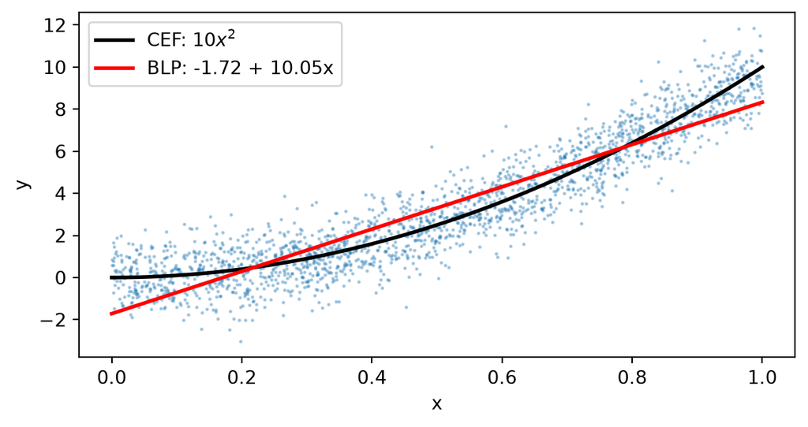

```python
n = 2_000
X = rng.random(n)                       # U(0,1)
Y = 10 * X ** 2 + rng.standard_normal(n)

b = np.cov(X, Y)[0, 1] / X.var()        # sample analogs of beta, alpha
a = Y.mean() - b * X.mean()

xs = np.linspace(0, 1, 100)
fig, ax = plt.subplots(figsize=(7, 3.4))
ax.plot(X, Y, '.', ms=2, alpha=0.3)
ax.plot(xs, 10 * xs ** 2, 'k', lw=2, label=r'CEF: $10x^2$')
ax.plot(xs, a + b * xs, 'r', lw=2, label=f'BLP: {a:.2f} + {b:.2f}x')
ax.set(xlabel='x', ylabel='y')
ax.legend()
plt.show()
```

## The BLP depends on the dist’n of X

- With a *nonlinear* CEF, changing the distribution of $X$ changes the BLP (Example 2.2.24)
- The BLP is a property of the joint distribution, not of the CEF alone
- Practical warning: a “slope” estimated where data are dense may extrapolate badly where data are sparse

## Independence, again

**Theorem 2.2.25 — Implications of Independence (Part III)**

If $X$ and $Y$ are independent random variables, then

- $\mathrm{E}[Y \mid X] = \mathrm{E}[Y]$.
- $\mathrm{V}[Y \mid X] = \mathrm{V}[Y]$.
- The BLP of $Y$ given $X$ is $\mathrm{E}[Y]$.
- Under independence, conditioning is useless: the best prediction ignores $X$ entirely

## Covariance matrices

**Definition 2.3.1 — Covariance Matrix**

For a random vector $\mathbf{X}$ of length $K$, the covariance matrix $\mathrm{V}[\mathbf{X}]$ is the matrix whose $(k, k')$-th entry is $\operatorname{Cov}[X_{[k]}, X_{[k']}]$.

$$\mathrm{V}[\mathbf{X}] = \begin{pmatrix}
\V[X_1] & \operatorname{Cov}[X_1, X_2] & \cdots & \operatorname{Cov}[X_1, X_K] \\
\operatorname{Cov}[X_2, X_1] & \V[X_2] & \cdots & \operatorname{Cov}[X_2, X_K] \\
\vdots & \vdots & \ddots & \vdots \\
\operatorname{Cov}[X_K, X_1] & \operatorname{Cov}[X_K, X_2] & \cdots & \V[X_k]
\end{pmatrix}$$

- The covariance matrix is symmetric; the diagonal entries are the variances of the individual components.